# MODELO FACTORIAL MULTIVARIANTE PARA LA ELABORACIÓN DE UN ÍNDICE MULTIDIMENSIONAL EN LAS COMUNIDADES DE MACROINVERTEBRADOS

Maestría en Biodiversidad y Cambio Climático

Autor/a

Marcelo Chávez

Fecha de publicación

25 de marzo de 2025

Resumen

En el presente Notebook de **R**, se desarrolla un proceso estadístico que aplica un **Modelo Factorial Multivariante** por Componentes Principales (**Analysis Component Principal - ACP**) y una **Clusterización** que determina la taxonomía de grupos de Ríos para las comunidades de macroinvertebrados con base a variables físico-químicas y ecológicas. El proceso que se desarrolla para reducir la dimensionalidad de los datos se basa en resumir la máxima variabilidad de los mismos. Adicionalmente, se empleará un algoritmo de **K-Means** para agrupar dichas variables en función de su similitud, permitiendo identificar grupos de variables y explorar sus posibles diferencias. Al integrar dichos métodos analíticos, esta investigación proporcionará una comprensión más profunda sobre el el comportamiento de las comunidades de macroinvertebrados. Finalmente, Los hallazgos de este análisis contribuirán a crear futuras estrategias de conservación y gestión en estos ecosistemas.

**Código**

```r
# Librerías y directorio de trabajo:
library(tidyverse)
library(DT)
library(highcharter)
library(psych)
library(gridExtra)
library(glue)
library(e1071)
library(reshape2)
library(factoextra)
library(FactoMineR)
library(corrplot)
library(knitr)
library(kableExtra)
library(RColorBrewer) # Librería para la paleta de colores

knitr::opts_knit$set(root.dir = "D:/DATA_SCIENCE_ENDI/ACP/")
```

# 1 Análisis Exploratorio de los Índices Físquico-Químicos y Ecológicos

Iniciaremos realizando un análisis gráfico mediante una técnica gráfica muy popular como lo es el **Boxplot** (Walpole et al. 2012) (Diagrama de caja y bigotes) comparativo, para visualizar si existen valores atípicos y como se distribuyen las variables en los años **1995 y 2021** según las escalas de medición originales en cada variable:

**Cuantiles:** Un cuantil de una muestra, $q(f)$, es un valor para el que una fracción específica $f$ de los valores de los datos es menor o igual a $q(f)$.

Un cuantil representa una estimación de una característica de una población o, más bien, la distribución teórica. La mediana de la muestra es $q(0.5)$. El percentil 75 (cuartil superior) es $q(0.75)$ y el cuantil inferior es $q(0.25)$. Una gráfica de cuantiles simplemente son los valores de los datos en el eje vertical contra una evaluación empírica de la fracción de observaciones excedidas por los valores de los datos (Walpole et al. 2012).

## 1.1 Dataset de los Índices Físico Químicos y Ecológicos:

**Código**

```r
# Carga del DataSet y transformaciones -----------------------------------------

indices_fq <- readxl::read_excel("DATASETS/DatosMacroinvertebrados.xlsx") %>%
  mutate_if(is.numeric, ~ round(., 2))

cols <- c("RIOS","ANIO")

df_largo <- indices_fq %>%
    pivot_longer(cols = -RIOS,
                 names_to = c(".value", "ANIO"),
                 names_pattern = "(.*)_(\\d{4})") %>%
  mutate_at(.vars = cols, .funs = factor)

indices_fq_ddc <- df_largo %>%
    mutate(ID = glue("{RIOS}_{ANIO}")) %>%
    column_to_rownames(var = "ID") %>%
    select(-RIOS,
           -ANIO)

var_scale <- as.data.frame(lapply(indices_fq_ddc, function(x) if(is.numeric(x)) scale(x) else x))

df_fq_1995 <- pivot_longer(df_largo,
                           cols = c(ANCHO,
                                    PROFUNDIDAD,
                                    VELOCIDAD,
                                    DESCARGA,
                                    PH,
                                    TEMPERATURA,
                                    OXIGENO_DISUELTO,
                                    CONDUCTIVIDAD,
                                    RIQUEZA,
                                    ABUNDANCIA,
                                    DIVERSIDAD,
                                    ABI,
                                    BMWP,
                                    IBF),
                           names_to = "VARIABLE",
                           values_to = "VALOR") %>%
    filter(ANIO=="1995")

df_fq_2021 <- pivot_longer(df_largo,
                           cols = c(ANCHO,
                                    PROFUNDIDAD,
                                    VELOCIDAD,
                                    DESCARGA,
                                    PH,
                                    TEMPERATURA,
                                    OXIGENO_DISUELTO,
                                    CONDUCTIVIDAD,
                                    RIQUEZA,
                                    ABUNDANCIA,
                                    DIVERSIDAD,
                                    ABI,
                                    BMWP,
                                    IBF),
                           names_to = "VARIABLE",
                           values_to = "VALOR") %>%
    filter(ANIO=="2021")


# Data para BoxPlot:

df_bx_95 <- data_to_boxplot(
    df_fq_1995,
    variable = VALOR,
    group_var = VARIABLE,
    # group_var2 = codigo,
    add_outliers = T
)

df_bx_21 <- data_to_boxplot(
    df_fq_2021,
    variable = VALOR,
    group_var = VARIABLE,
    # group_var2 = codigo,
    add_outliers = T
)

# Visualización del Dataset

DT::datatable(df_largo,
              class = 'cell-border stripe',
              # filter = 'top',
              caption = htmltools::tags$caption(
              style = 'caption-side: bottom; text-align: left;',
              'Tabla: ', htmltools::em('Indicadores Físico-Químicos y Ecológicos para los años 1995 y 2021')),
              extensions = c('Buttons','Scroller'),
              options = list(scrollX = TRUE,
                             initComplete = JS(
    "function(settings, json) {",
    "$(this.api().table().header()).css({'background-color': '#003566', 'color': '#fff'});",
    "}"),
    dom = 'Bfrtip',
    buttons = c('excel'),
    deferRender = TRUE,
    scrollY = 500,
    scroller = TRUE))
```

|  | RIOS | ANIO | ANCHO | PROFUNDIDAD | VELOCIDAD | DESCARGA | PH | TEMPERATURA | OXIGENO_DISUELTO | CONDUCTIVIDAD | RIQUEZA | ABUNDANCIA | DIVERSIDAD | ABI | BMWP | IBF |
| --- | --- | --- | --- | --- | --- | --- | --- | --- | --- | --- | --- | --- | --- | --- | --- | --- |
| 1 | PMB_01 | 1995 | 2.1 | 0.11 | 0.16 | 52 | 8.15 | 14.8 | 6.3 | 48 | 12 | 2926 | 1.61 | 36 | 43 | 3.2 |
| 2 | PMB_01 | 2021 | 3.4 | 0.26 | 0.76 | 671.84 | 7.7 | 10.3 | 7.9 | 18 | 7 | 85 | 1.63 | 26 | 34 | 3.71 |
| 3 | PMB_02 | 1995 | 1.93 | 0.27 | 0.53 | 289 | 7.4 | 9 | 7.4 | 19 | 12 | 564 | 1.5 | 42 | 33 | 4.54 |
| 4 | PMB_02 | 2021 | 2.07 | 0.26 | 1.38 | 742.72 | 7.74 | 13.1 | 7.43 | 16.7 | 3 | 15 | 0.63 | 12 | 12 | 1.33 |
| 5 | PMB_03 | 1995 | 1.23 | 0.07 | 0.05 | 5 | 6.18 | 9.9 | 6.8 | 48 | 10 | 335 | 1.77 | 45 | 57 | 4.44 |
| 6 | PMB_03 | 2021 | 1.16 | 0.25 | 0.53 | 153.7 | 7.54 | 11.7 | 7.63 | 33.8 | 5 | 93 | 0.62 | 18 | 19 | 1.01 |
| 7 | PMB_04 | 1995 | 1.9 | 0.17 | 0.12 | 34 | 6.36 | 12.6 | 6.6 | 39 | 10 | 445 | 1.2 | 33 | 33 | 5.36 |
| 8 | PMB_04 | 2021 | 1.26 | 0.16 | 0.03 | 6.65 | 7.2 | 6.9 | 7.53 | 21 | 5 | 113 | 1.48 | 26 | 32 | 4.57 |
| 9 | PMB_05 | 1995 | 1.73 | 0.23 | 0.34 | 87 | 8.22 | 11.2 | 7.5 | 57 | 16 | 2773 | 1.6 | 71 | 78 | 3.1 |
| 10 | PMB_05 | 2021 | 2.77 | 0.22 | 0.05 | 30.47 | 8.21 | 9.6 | 8.28 | 60.7 | 7 | 414 | 1.49 | 31 | 31 | 2.37 |

[output cut: 12 more lines]

## 1.2 Boxplot de los indicadores físico-químicos y ecológicos:

### 1.2.1 Año 1995

Para el gráfico de los **Boxplot** se obtiene de la siguiente estructura de datos:

**Código**

```r
estadisticos_boxplot <- function(df, year) {

  df <- subset(df, ANIO == year)
  df <- df[sapply(df, is.numeric)]

  cuartiles <- as.data.frame(apply(df, 2, quantile, probs = c(0.25, 0.5, 0.75)))
  rownames(cuartiles) <- c("Q1", "Q2", "Q3")

  minimos <- as.data.frame(t(apply(df, 2, min)))
  rownames(minimos) <- "Mínimo"

  maximos <- as.data.frame(t(apply(df, 2, max)))
  rownames(maximos) <- "Máximo"

  estadisticos <- rbind(cuartiles,
                        minimos,
                        maximos)

  # Redondear los valores
  estadisticos <- round(estadisticos, 2)

  # Añadir los nombres de las estadísticas como una columna
  estadisticos$ESTADISTICOS <- rownames(estadisticos)

  # Reorganizar las columnas
  estadisticos <- estadisticos %>%
    select(ESTADISTICOS, everything())

  rownames(estadisticos) <- NULL

  return(estadisticos)

}

# Ejemplo de uso
cuartiles_95 <- estadisticos_boxplot(df_largo, "1995")

DT::datatable(cuartiles_95,
              class = 'cell-border stripe',
              # filter = 'top',
              caption = htmltools::tags$caption(
              style = 'caption-side: bottom; text-align: left;',
              'Tabla: ', htmltools::em('Estadísticos del Boxplot - Año 1995')),
              extensions = c('Buttons','Scroller'),
              options = list(scrollX = FALSE,
                             initComplete = JS(
    "function(settings, json) {",
    "$(this.api().table().header()).css({'background-color': '#003566', 'color': '#fff'});",
    "}"),
    dom = 'Bfrtip',
    buttons = c('excel')))
```

|  | ESTADISTICOS | ANCHO | PROFUNDIDAD | VELOCIDAD | DESCARGA | PH | TEMPERATURA | OXIGENO_DISUELTO | CONDUCTIVIDAD | RIQUEZA | ABUNDANCIA | DIVERSIDAD | ABI | BMWP | IBF |
| --- | --- | --- | --- | --- | --- | --- | --- | --- | --- | --- | --- | --- | --- | --- | --- |
| 1 | Q1 | 1.78 | 0.16 | 0.14 | 39 | 7.47 | 9.3 | 6.7 | 38.5 | 11 | 500.5 | 1.44 | 39 | 38 | 3.57 |
| 2 | Q2 | 1.93 | 0.17 | 0.2 | 87 | 7.63 | 10.6 | 7.1 | 48 | 13 | 598 | 1.6 | 61 | 49 | 4.44 |
| 3 | Q3 | 2.7 | 0.18 | 0.32 | 183.5 | 8.03 | 11.85 | 7.45 | 63 | 15 | 1557 | 1.72 | 71.5 | 67 | 4.86 |
| 4 | Mínimo | 1.23 | 0.07 | 0.05 | 5 | 6.18 | 6.4 | 6.3 | 19 | 8 | 335 | 0.85 | 17 | 17 | 2 |
| 5 | Máximo | 6 | 0.27 | 0.53 | 298 | 8.25 | 14.8 | 7.7 | 119 | 20 | 2926 | 2.05 | 102 | 86 | 6.22 |

**Código**

```r
highchart() %>%
    hc_xAxis(type = "category",
             labels = list(
                 rotation = 270
             )) %>%
    hc_add_series_list(df_bx_95) %>%
    hc_xAxis(title = list(text = "VARIABLES")) %>%
    hc_yAxis(title = list(text = "VALORES")) %>%
    hc_title(text = "BOXPLOT COMPARATIVO ENTRE VARIABLES FÍSICO QUÍMICAS y ECOLÓGICAS - AÑO 1995") %>%
    hc_subtitle(text = "AÑO 1995", align="left") %>%
    hc_caption(text = "ELABORADO POR: Marcelo Chávez") %>%
    hc_legend(enabled = F, title = list(text = "<b>ESTACIONES DE MONITOREO:</b>")) %>%
    hc_tooltip(formatter = JS("function() {
    var tooltip = '';
    if (this.point.low && this.point.q1 && this.point.median && this.point.q3 && this.point.high) {
        tooltip += '<b>Variable: </b>' + this.point.name + '<br/>' +
                   '<b>Mínimo: </b>' + this.point.low.toFixed(2) + '</b><br/>' +
                   '<b>Q1: </b>' + this.point.q1.toFixed(2) + '</b><br/>' +
                   '<b>Mediana: </b>' + this.point.median.toFixed(2) + '</b><br/>' +
                   '<b>Q3: </b>' + this.point.q3.toFixed(2) + '</b><br/>' +
                   '<b>Máximo: </b>' + this.point.high.toFixed(2) + '</b><br/>';
    }
    if (this.point.y && !(this.point.low && this.point.q1 && this.point.median && this.point.q3 && this.point.high)) {
        tooltip += '<b>Valor Atípico: </b>' + this.point.y.toFixed(2) + '<br/>';
    }
    return tooltip;}")) %>%
    hc_add_theme(hc_theme_gridlight())
```

[interactive chart not shown]

**Análisis por variable del año 1995**

#### **1. Variable: Descarga**

La descarga de agua en el río presenta la siguiente distribución:

- El primer cuartil (Q1) de la descarga es de 39 metros cúbicos por segundo, lo que indica que el 25% de las mediciones de descarga son iguales o inferiores a este valor.
- La mediana (Q2) de la descarga es de 87 metros cúbicos por segundo, lo que significa que el 50% de las mediciones son iguales o inferiores a este valor.
- El tercer cuartil (Q3) de la descarga es de 183.5 metros cúbicos por segundo, lo que indica que el 75% de las mediciones son iguales o inferiores a este valor.
- El mínimo de la descarga es de 5 metros cúbicos por segundo, mientras que el máximo es de 298 metros cúbicos por segundo.

#### **2. Variable: *pH***

El pH del agua en el río muestra la siguiente distribución:

- El primer cuartil (Q1) del pH es de 7.47, lo que indica que el 25% de las mediciones de pH son iguales o inferiores a este valor.
- La mediana (Q2) del pH es de 7.63, lo que significa que el 50% de las mediciones son iguales o inferiores a este valor.
- El tercer cuartil (Q3) del pH es de 8.03, lo que indica que el 75% de las mediciones son iguales o inferiores a este valor.
- El mínimo del pH es de 6.18, mientras que el máximo es de 8.25.

#### **4. Variable: *Oxígeno Disuelto***

El oxígeno disuelto en el agua del río muestra la siguiente distribución:

- El primer cuartil (Q1) del oxígeno disuelto es de 6.7 mg/L, lo que indica que el 25% de las mediciones de oxígeno disuelto son iguales o inferiores a este valor.
- La mediana (Q2) del oxígeno disuelto es de 7.1 mg/L, lo que significa que el 50% de las mediciones son iguales o inferiores a este valor.
- El tercer cuartil (Q3) del oxígeno disuelto es de 7.45 mg/L, lo que indica que el 75% de las mediciones son iguales o inferiores a este valor.
- El mínimo del oxígeno disuelto es de 6.3 mg/L, mientras que el máximo es de 7.7 mg/L.

#### **5. Variable: *Conductividad***

La conductividad del agua en el río exhibe la siguiente distribución:

- El primer cuartil (Q1) de la conductividad es de 38.5 μS/cm, lo que indica que el 25% de las mediciones de conductividad son iguales o inferiores a este valor.
- La mediana (Q2) de la conductividad es de 48 μS/cm, lo que significa que el 50% de las mediciones son iguales o inferiores a este valor.
- El tercer cuartil (Q3) de la conductividad es de 63 μS/cm, lo que indica que el 75% de las mediciones son iguales o inferiores a este valor.
- El mínimo de la conductividad es de 19 μS/cm, mientras que el máximo es de 119 μS/cm.

#### **6. Variable: *Riqueza***

La riqueza de especies de macroinvertebrados en el río muestra la siguiente distribución:

- El primer cuartil (Q1) de la riqueza es de 11 especies, lo que indica que el 25% de las mediciones de riqueza son iguales o inferiores a este valor.
- La mediana (Q2) de la riqueza es de 13 especies, lo que significa que el 50% de las mediciones son iguales o inferiores a este valor.
- El tercer cuartil (Q3) de la riqueza es de 15 especies, lo que indica que el 75% de las mediciones son iguales o inferiores a este valor.
- El mínimo de la riqueza es de 8 especies, mientras que el máximo es de 20 especies.

#### **7. Variable: *Abundancia***

La abundancia de macroinvertebrados en el río muestra la siguiente distribución:

- El primer cuartil (Q1) de la abundancia es de 500.5 individuos, lo que indica que el 25% de las mediciones de abundancia son iguales o inferiores a este valor.
- La mediana (Q2) de la abundancia es de 598 individuos, lo que significa que el 50% de las mediciones son iguales o inferiores a este valor.
- El tercer cuartil (Q3) de la abundancia es de 1557 individuos, lo que indica que el 75% de las mediciones son iguales o inferiores a este valor.
- El mínimo de la abundancia es de 335 individuos, mientras que el máximo es de 2926 individuos.

#### **8. Variable: *Diversidad***

La diversidad de especies de macroinvertebrados en el río exhibe la siguiente distribución:

- El primer cuartil (Q1) de la diversidad es de 1.44, lo que indica que el 25% de las mediciones de diversidad son iguales o inferiores a este valor.
- La mediana (Q2) de la diversidad es de 1.6, lo que significa que el 50% de las mediciones son iguales o inferiores a este valor.
- El tercer cuartil (Q3) de la diversidad es de 1.72, lo que indica que el 75% de las mediciones son iguales o inferiores a este valor.
- El mínimo de la diversidad es de 0.85, mientras que el máximo es de 2.05.

#### **9. Variable: *ABI***

El Índice de Bioticidad del Agua (ABI) en el río muestra la siguiente distribución:

- El primer cuartil (Q1) del ABI es de 39, lo que indica que el 25% de las mediciones de ABI son iguales o inferiores a este valor.
- La mediana (Q2) del ABI es de 61, lo que significa que el 50% de las mediciones son iguales o inferiores a este valor.
- El tercer cuartil (Q3) del ABI es de 71.5, lo que indica que el 75% de las mediciones son iguales o inferiores a este valor.
- El mínimo del ABI es de 17, mientras que el máximo es de 102.

#### **10. Variable: *BMWP***

El Índice de Calidad del Agua del Macroinvertebrados Bentónicos (BMWP) en el río muestra la siguiente distribución:

- El primer cuartil (Q1) del BMWP es de 38, lo que indica que el 25% de las mediciones de BMWP son iguales o inferiores a este valor.
- La mediana (Q2) del BMWP es de 49, lo que significa que el 50% de las mediciones son iguales o inferiores a este valor.
- El tercer cuartil (Q3) del BMWP es de 67, lo que indica que el 75% de las mediciones son iguales o inferiores a este valor.
- El mínimo del BMWP es de 17, mientras que el máximo es de 86.

#### **11. Variable: *IBF***

El Índice Biótico de Familias (IBF) en el río muestra la siguiente distribución:

- El primer cuartil (Q1) del IBF es de 3.57, lo que indica que el 25% de las mediciones de IBF son iguales o inferiores a este valor.
- La mediana (Q2) del IBF es de 4.44, lo que significa que el 50% de las mediciones son iguales o inferiores a este valor.
- El tercer cuartil (Q3) del IBF es de 4.86, lo que indica que el 75% de las mediciones son iguales o inferiores a este valor.
- El mínimo del IBF es de 2, mientras que el máximo es de 6.22.

#### **12. Variable: *Ancho***

El ancho de los ríos muestra la siguiente distribución:

- El primer cuartil (Q1) del ancho del río es de 1.78 metros, lo que indica que el 25% de los datos de ancho del río son iguales o inferiores a este valor.
- La mediana (Q2) del ancho del río es de 1.93 metros, lo que significa que el 50% de los datos son iguales o inferiores a este valor.
- El tercer cuartil (Q3) del ancho del río es de 2.7 metros, lo que indica que el 75% de los datos son iguales o inferiores a este valor.
- El mínimo del ancho del río es de 1.23 metros, mientras que el máximo es de 6 metros.

#### **13. Variable: *Profundidad***

La profundidad en los ríos muestra la siguiente distribución:

- El primer cuartil (Q1) de la profundidad del río es de 0.16 metros, lo que indica que el 25% de los datos de profundidad del río son iguales o inferiores a este valor.
- La mediana (Q2) de la profundidad del río es de 0.17 metros, lo que significa que el 50% de los datos son iguales o inferiores a este valor.
- El tercer cuartil (Q3) de la profundidad del río es de 0.18 metros, lo que indica que el 75% de los datos son iguales o inferiores a este valor.
- El mínimo de la profundidad del río es de 0.07 metros, mientras que el máximo es de 0.27 metros.

#### **14. Variable: *Velocidad***

La velocidad en los ríos muestra la siguiente distribución:

El primer cuartil (Q1) de la velocidad del agua en el río es de 0.14 metros por segundo, lo que indica que el 25% de los datos de velocidad del agua en el río son iguales o inferiores a este valor.

La mediana (Q2) de la velocidad del agua en el río es de 0.2 metros por segundo, lo que significa que el 50% de los datos son iguales o inferiores a este valor.

El tercer cuartil (Q3) de la velocidad del agua en el río es de 0.32 metros por segundo, lo que indica que el 75% de los datos son iguales o inferiores a este valor.

El mínimo de la velocidad del agua en el río es de 0.05 metros por segundo, mientras que el máximo es de 0.53 metros por segundo.

### 1.2.2 Año 2021

Para el gráfico de los **Boxplot** se obtiene de la siguiente estructura de datos:

**Código**

```r
# Calcula los estadísticos para graficar un boxplot
cuartiles_21 <- estadisticos_boxplot(df_largo, "2021")

DT::datatable(cuartiles_21,
              class = 'cell-border stripe',
              # filter = 'top',
              caption = htmltools::tags$caption(
              style = 'caption-side: bottom; text-align: left;',
              'Tabla: ', htmltools::em('Estadísticos del Boxplot - Año 2021')),
              extensions = c('Buttons','Scroller'),
              options = list(scrollX = FALSE,
                             initComplete = JS(
    "function(settings, json) {",
    "$(this.api().table().header()).css({'background-color': '#003566', 'color': '#fff'});",
    "}"),
    dom = 'Bfrtip',
    buttons = c('excel')))
```

|  | ESTADISTICOS | ANCHO | PROFUNDIDAD | VELOCIDAD | DESCARGA | PH | TEMPERATURA | OXIGENO_DISUELTO | CONDUCTIVIDAD | RIQUEZA | ABUNDANCIA | DIVERSIDAD | ABI | BMWP | IBF |
| --- | --- | --- | --- | --- | --- | --- | --- | --- | --- | --- | --- | --- | --- | --- | --- |
| 1 | Q1 | 1.63 | 0.22 | 0.15 | 87.4 | 7.62 | 8.65 | 7.53 | 27.4 | 5 | 82 | 0.8 | 18.5 | 20.5 | 1.85 |
| 2 | Q2 | 2.39 | 0.26 | 0.2 | 291.34 | 7.74 | 9.6 | 7.63 | 41.6 | 6 | 98 | 1.46 | 26 | 31 | 3.71 |
| 3 | Q3 | 4.2 | 0.33 | 0.53 | 489.75 | 8.07 | 10.8 | 7.88 | 59.6 | 7.5 | 173.5 | 1.5 | 32.5 | 33 | 5.97 |
| 4 | Mínimo | 1 | 0.16 | 0.03 | 6.65 | 7.2 | 6.5 | 5.1 | 16.7 | 3 | 15 | 0.32 | 12 | 12 | 0.42 |
| 5 | Máximo | 7 | 0.5 | 1.38 | 742.72 | 8.52 | 13.1 | 8.28 | 82 | 8 | 414 | 1.63 | 41 | 42 | 6.76 |

**Código**

```r
highchart() %>%
    hc_xAxis(type = "category",
             labels = list(
                 rotation = 270
             )) %>%
    hc_add_series_list(df_bx_21) %>%
    hc_xAxis(title = list(text = "VARIABLES")) %>%
    hc_yAxis(title = list(text = "VALORES")) %>%
    hc_title(text = "BOXPLOT COMPARATIVO ENTRE ÍNDICES FÍSICO QUÍMICOS y ECOLÓGICOS - AÑO 2021") %>%
    hc_subtitle(text = "AÑO 2021", align="left") %>%
    hc_caption(text = "ELABORADO POR: Marcelo Chávez") %>%
    hc_legend(enabled = F, title = list(text = "<b>ESTACIONES DE MONITOREO:</b>")) %>%
    hc_tooltip(formatter = JS("function() {
    var tooltip = '';
    if (this.point.low && this.point.q1 && this.point.median && this.point.q3 && this.point.high) {
        tooltip += '<b>Variable: </b>' + this.point.name + '<br/>' +
                   '<b>Mínimo: </b>' + this.point.low.toFixed(2) + '</b><br/>' +
                   '<b>Q1: </b>' + this.point.q1.toFixed(2) + '</b><br/>' +
                   '<b>Mediana: </b>' + this.point.median.toFixed(2) + '</b><br/>' +
                   '<b>Q3: </b>' + this.point.q3.toFixed(2) + '</b><br/>' +
                   '<b>Máximo: </b>' + this.point.high.toFixed(2) + '</b><br/>';
    }
    if (this.point.y && !(this.point.low && this.point.q1 && this.point.median && this.point.q3 && this.point.high)) {
        tooltip += '<b>Valor Atípico: </b>' + this.point.y.toFixed(2) + '<br/>';
    }
    return tooltip;}")) %>%
    hc_add_theme(hc_theme_gridlight())
```

[interactive chart not shown]

**Análisis por variable del año 2021**

#### **1. Variable: Ancho**

El ancho del río muestra la siguiente distribución:

- El primer cuartil (Q1) del ancho es de 1.63 metros, lo que indica que el 25% de las mediciones de ancho son iguales o inferiores a este valor.
- La mediana (Q2) del ancho es de 2.39 metros, lo que significa que el 50% de las mediciones son iguales o inferiores a este valor.
- El tercer cuartil (Q3) del ancho es de 4.2 metros, lo que indica que el 75% de las mediciones son iguales o inferiores a este valor.
- El mínimo del ancho es de 1 metro, mientras que el máximo es de 7 metros.

#### **2. Variable: Profundidad**

La profundidad del río muestra la siguiente distribución:

- El primer cuartil (Q1) de la profundidad es de 0.22 metros, lo que indica que el 25% de las mediciones de profundidad son iguales o inferiores a este valor.
- La mediana (Q2) de la profundidad es de 0.26 metros, lo que significa que el 50% de las mediciones son iguales o inferiores a este valor.
- El tercer cuartil (Q3) de la profundidad es de 0.33 metros, lo que indica que el 75% de las mediciones son iguales o inferiores a este valor.
- El mínimo de la profundidad es de 0.16 metros, mientras que el máximo es de 0.5 metros.

#### **3. Variable: Velocidad**

La velocidad del agua en el río muestra la siguiente distribución:

- El primer cuartil (Q1) de la velocidad es de 0.15 metros por segundo, lo que indica que el 25% de las mediciones de velocidad son iguales o inferiores a este valor.
- La mediana (Q2) de la velocidad es de 0.2 metros por segundo, lo que significa que el 50% de las mediciones son iguales o inferiores a este valor.
- El tercer cuartil (Q3) de la velocidad es de 0.53 metros por segundo, lo que indica que el 75% de las mediciones son iguales o inferiores a este valor.
- El mínimo de la velocidad es de 0.03 metros por segundo, mientras que el máximo es de 1.38 metros por segundo.

#### **4. Variable: Descarga**

La descarga de agua en el río muestra la siguiente distribución:

- El primer cuartil (Q1) de la descarga es de 87.4 metros cúbicos por segundo, lo que indica que el 25% de las mediciones de descarga son iguales o inferiores a este valor.
- La mediana (Q2) de la descarga es de 291.34 metros cúbicos por segundo, lo que significa que el 50% de las mediciones son iguales o inferiores a este valor.
- El tercer cuartil (Q3) de la descarga es de 489.75 metros cúbicos por segundo, lo que indica que el 75% de las mediciones son iguales o inferiores a este valor.
- El mínimo de la descarga es de 6.65 metros cúbicos por segundo, mientras que el máximo es de 742.72 metros cúbicos por segundo.

#### **5. Variable: pH**

El pH del agua en el río muestra la siguiente distribución:

- El primer cuartil (Q1) del pH es de 7.62, lo que indica que el 25% de las mediciones de pH son iguales o inferiores a este valor.
- La mediana (Q2) del pH es de 7.74, lo que significa que el 50% de las mediciones son iguales o inferiores a este valor.
- El tercer cuartil (Q3) del pH es de 8.07, lo que indica que el 75% de las mediciones son iguales o inferiores a este valor.
- El mínimo del pH es de 7.2, mientras que el máximo es de 8.52.

#### **6. Variable: Temperatura**

La temperatura del agua en el río muestra la siguiente distribución:

- El primer cuartil (Q1) de la temperatura es de 8.65 grados Celsius, lo que indica que el 25% de las mediciones de temperatura son iguales o inferiores a este valor.
- La mediana (Q2) de la temperatura es de 9.6 grados Celsius, lo que significa que el 50% de las mediciones son iguales o inferiores a este valor.
- El tercer cuartil (Q3) de la temperatura es de 10.8 grados Celsius, lo que indica que el 75% de las mediciones son iguales o inferiores a este valor.
- El mínimo de la temperatura es de 6.5 grados Celsius, mientras que el máximo es de 13.1 grados Celsius.

#### **7. Variable: Oxígeno Disuelto**

El oxígeno disuelto en el agua del río muestra la siguiente distribución:

- El primer cuartil (Q1) del oxígeno disuelto es de 7.53 mg/L, lo que indica que el 25% de las mediciones de oxígeno disuelto son iguales o inferiores a este valor.
- La mediana (Q2) del oxígeno disuelto es de 7.63 mg/L, lo que significa que el 50% de las mediciones son iguales o inferiores a este valor.
- El tercer cuartil (Q3) del oxígeno disuelto es de 7.88 mg/L, lo que indica que el 75% de las mediciones son iguales o inferiores a este valor.
- El mínimo del oxígeno disuelto es de 5.1 mg/L, mientras que el máximo es de 8.28 mg/L.

#### **8. Variable: Conductividad**

La conductividad del agua en el río muestra la siguiente distribución:

- El primer cuartil (Q1) de la conductividad es de 27.4 µS/cm, lo que indica que el 25% de las mediciones de conductividad son iguales o inferiores a este valor.
- La mediana (Q2) de la conductividad es de 41.6 µS/cm, lo que significa que el 50% de las mediciones son iguales o inferiores a este valor.
- El tercer cuartil (Q3) de la conductividad es de 59.6 µS/cm, lo que indica que el 75% de las mediciones son iguales o inferiores a este valor.
- El mínimo de la conductividad es de 16.7 µS/cm, mientras que el máximo es de 82 µS/cm.

#### **9. Variable: Riqueza**

La riqueza de especies de macroinvertebrados en el río muestra la siguiente distribución:

- El primer cuartil (Q1) de la riqueza es de 5 especies, lo que indica que el 25% de las mediciones de riqueza son iguales o inferiores a este valor.
- La mediana (Q2) de la riqueza es de 6 especies, lo que significa que el 50% de las mediciones son iguales o inferiores a este valor.
- El tercer cuartil (Q3) de la riqueza es de 7.5 especies, lo que indica que el 75% de las mediciones son iguales o inferiores a este valor.
- El mínimo de la riqueza es de 3 especies, mientras que el máximo es de 8 especies.

#### **10. Variable: Abundancia**

La abundancia de macroinvertebrados en el río muestra la siguiente distribución:

- El primer cuartil (Q1) de la abundancia es de 82 individuos, lo que indica que el 25% de las mediciones de abundancia son iguales o inferiores a este valor.
- La mediana (Q2) de la abundancia es de 98 individuos, lo que significa que el 50% de las mediciones son iguales o inferiores a este valor.
- El tercer cuartil (Q3) de la abundancia es de 173.5 individuos, lo que indica que el 75% de las mediciones son iguales o inferiores a este valor.
- El mínimo de la abundancia es de 15 individuos, mientras que el máximo es de 414 individuos.

#### **11. Variable: Diversidad**

La diversidad de especies de macroinvertebrados en el río muestra la siguiente distribución:

- El primer cuartil (Q1) de la diversidad es de 0.8, lo que indica que el 25% de las mediciones de diversidad son iguales o inferiores a este valor.
- La mediana (Q2) de la diversidad es de 1.46, lo que significa que el 50% de las mediciones son iguales o inferiores a este valor.
- El tercer cuartil (Q3) de la diversidad es de 1.5, lo que indica que el 75% de las mediciones son iguales o inferiores a este valor.
- El mínimo de la diversidad es de 0.32, mientras que el máximo es de 1.63.

#### **12. Variable: ABI**

El Índice de Bioticidad (ABI) en el río muestra la siguiente distribución:

- El primer cuartil (Q1) del ABI es de 18.5, lo que indica que el 25% de las mediciones de ABI son iguales o inferiores a este valor.
- La mediana (Q2) del ABI es de 26, lo que significa que el 50% de las mediciones son iguales o inferiores a este valor.
- El tercer cuartil (Q3) del ABI es de 32.5, lo que indica que el 75% de las mediciones son iguales o inferiores a este valor.
- El mínimo del ABI es de 12, mientras que el máximo es de 41.

#### **13. Variable: BMWP**

El índice de BMWP (Biological Monitoring Working Party) en el río muestra la siguiente distribución:

- El primer cuartil (Q1) del índice BMWP es de 20.5, lo que indica que el 25% de las mediciones de BMWP son iguales o inferiores a este valor.
- La mediana (Q2) del índice BMWP es de 31, lo que significa que el 50% de las mediciones son iguales o inferiores a este valor.
- El tercer cuartil (Q3) del índice BMWP es de 33, lo que indica que el 75% de las mediciones son iguales o inferiores a este valor.
- El mínimo del índice BMWP es de 12, mientras que el máximo es de 42.

#### **14. Variable: IBF**

El Índice Biótico de Familias (IBF) en el río muestra la siguiente distribución:

- El primer cuartil (Q1) del IBF es de 1.85, lo que indica que el 25% de las mediciones de IBF son iguales o inferiores a este valor.
- La mediana (Q2) del IBF es de 3.71, lo que significa que el 50% de las mediciones son iguales o inferiores a este valor.
- El tercer cuartil (Q3) del IBF es de 5.97, lo que indica que el 75% de las mediciones son iguales o inferiores a este valor.
- El mínimo del IBF es de 0.42, mientras que el máximo es de 6.76.

## 1.3 Exploratorio de los datos:

El Análisis Exploratorio de los datos es relevante para determinar el comportamiento y naturaleza de las variables, podemos observar su distribución a través de medidas de localización y variabilidad (Walpole et al. 2012)

**Código**

```r
exploratorio <- function(df) {
    tipos <- sapply(df, class)
    valores_min <- sapply(df, function(x) ifelse(is.numeric(x), min(x[complete.cases(x)]), NA))
    valores_max <- sapply(df, function(x) ifelse(is.numeric(x), max(x[complete.cases(x)]), NA))
    coeficientes_asimetria <- sapply(df, function(x) ifelse(is.numeric(x), round(e1071::skewness(x[complete.cases(x)]), 2), NA))
    curtosis <- sapply(df, function(x) ifelse(is.numeric(x), round(kurtosis(x[complete.cases(x)]), 2), NA))
    promedio <- sapply(df, function(x) ifelse(is.numeric(x), round(mean(x[complete.cases(x)]), 2), NA))
    medianas <- sapply(df, function(x) ifelse(is.numeric(x), round(median(x[complete.cases(x)]), 2), NA))
    modas <- sapply(df, function(x) ifelse(is.numeric(x), {
        tab <- table(x[complete.cases(x)])
        as.numeric(names(tab)[tab == max(tab)])}, NA))
    rangos <- sapply(df, function(x) ifelse(is.numeric(x), round(max(x[complete.cases(x)]) - min(x[complete.cases(x)]), 2), NA))
    varianzas <- sapply(df, function(x) ifelse(is.numeric(x), round(var(x[complete.cases(x)]), 2), NA))
    desviaciones <- sapply(df, function(x) ifelse(is.numeric(x), round(sd(x[complete.cases(x)]), 2), NA))
    coeficientes_variacion <- sapply(df, function(x) ifelse(is.numeric(x), round(sd(x[complete.cases(x)]) / mean(x[complete.cases(x)]), 2), NA))

    resumen <- data.frame(Variable = names(df),
                          Tipo = tipos,
                          Minimo = valores_min,
                          Maximo = valores_max,
                          Rango = rangos,
                          Promedio = promedio,
                          Mediana = medianas,
                          Desviacion_Estandar = desviaciones,
                          Coeficiente_Variacion = coeficientes_variacion,
                          Moda = modas,
                          Varianza = varianzas,
                          Coeficiente_Asimetria = coeficientes_asimetria,
                          Curtosis = curtosis,
                          stringsAsFactors = FALSE)

    resumen$Tipo <- ifelse(resumen$Tipo == "factor", "Categórica", resumen$Tipo)
    resumen$Tipo <- ifelse(resumen$Tipo == "POSIXct", "Fecha", resumen$Tipo)
    resumen$Tipo <- ifelse(resumen$Tipo == "logical", "Booleana", resumen$Tipo)
    resumen$Tipo <- ifelse(resumen$Tipo == "numeric", "Numérica", resumen$Tipo)

    # Elimina los nombres de las etiquetas de las filas
    rownames(resumen) <- NULL

    return(resumen)
}

DT::datatable(exploratorio(df_largo),
              class = 'cell-border stripe',
              # filter = 'top',
              caption = htmltools::tags$caption(
              style = 'caption-side: bottom; text-align: left;',
              'Tabla: ', htmltools::em('Estimadores de Tendencia Central, Dispersión y Forma')),
              extensions = c('Buttons','Scroller'),
              options = list(scrollX = TRUE,
                             initComplete = JS(
    "function(settings, json) {",
    "$(this.api().table().header()).css({'background-color': '#003566', 'color': '#fff'});",
    "}"),
    dom = 'Bfrtip',
    buttons = c('excel'),
    deferRender = TRUE,
    scrollY = 500,
    scroller = TRUE))
```

|  | Variable | Tipo | Minimo | Maximo | Rango | Promedio | Mediana | Desviacion_Estandar | Coeficiente_Variacion | Moda | Varianza | Coeficiente_Asimetria | Curtosis |
| --- | --- | --- | --- | --- | --- | --- | --- | --- | --- | --- | --- | --- | --- |
| 1 | RIOS | Categórica |  |  |  |  |  |  |  |  |  |  |  |
| 2 | ANIO | Categórica |  |  |  |  |  |  |  |  |  |  |  |
| 3 | ANCHO | Numérica | 1 | 7 | 6 | 2.77 | 2.08 | 1.73 | 0.63 | 1.23 | 3 | 1.14 | 0.04 |
| 4 | PROFUNDIDAD | Numérica | 0.07 | 0.5 | 0.43 | 0.23 | 0.22 | 0.1 | 0.44 | 0.16 | 0.01 | 1.04 | 0.72 |
| 5 | VELOCIDAD | Numérica | 0.03 | 1.38 | 1.35 | 0.31 | 0.2 | 0.3 | 0.97 | 0.2 | 0.09 | 2.08 | 4.54 |
| 6 | DESCARGA | Numérica | 5 | 742.72 | 737.72 | 212.12 | 121.5 | 220.19 | 1.04 | 5 | 48483.77 | 1.12 | 0.07 |
| 7 | PH | Numérica | 6.18 | 8.52 | 2.34 | 7.69 | 7.74 | 0.57 | 0.07 | 7.4 | 0.32 | -1.15 | 1.08 |
| 8 | TEMPERATURA | Numérica | 6.4 | 14.8 | 8.4 | 10.15 | 10.1 | 2.11 | 0.21 | 9 | 4.46 | 0.07 | -0.44 |
| 9 | OXIGENO_DISUELTO | Numérica | 5.1 | 8.28 | 3.18 | 7.27 | 7.5 | 0.7 | 0.1 | 6.6 | 0.49 | -1.32 | 1.9 |
| 10 | CONDUCTIVIDAD | Numérica | 16.7 | 119 | 102.3 | 48.65 | 44.8 | 24.5 | 0.5 | 39 | 600.35 | 0.97 | 0.86 |

[output cut: 6 more lines]

#### **De las medidas del Análisis Exploratorio tanto para tendencia central, como de dispersión se puede deducir lo siguiente:**

**1. Variable: ANCHO**

La variable de ancho presenta la siguiente información:

- El promedio del ancho es de 2.77 metros, lo que indica que, en promedio, el ancho de los ríos analizados es de aproximadamente 2.77 metros.
- La mediana del ancho es de 2.08 metros, lo que sugiere que la mitad de las mediciones de ancho están por debajo de este valor.
- La desviación estándar del ancho es de 1.73 metros, lo que indica una moderada dispersión de los datos alrededor de la media.
- El coeficiente de variación del ancho es de 0.63, lo que sugiere una variabilidad moderada en relación con el promedio.
- El coeficiente de asimetría del ancho es positivo (1.14), lo que indica una ligera asimetría hacia la derecha en la distribución de los datos.
- La curtosis del ancho es cercana a 0.04, lo que sugiere una distribución casi normal.

#### **2. Variable: PROFUNDIDAD**

La variable de profundidad presenta la siguiente información:

- El promedio de la profundidad es de 0.23 metros, lo que indica que, en promedio, la profundidad de los ríos analizados es de aproximadamente 0.23 metros.
- La mediana de la profundidad es de 0.22 metros, lo que sugiere que la mitad de las mediciones de profundidad están por debajo de este valor.
- La desviación estándar de la profundidad es de 0.1 metros, lo que indica una baja dispersión de los datos alrededor de la media.
- El coeficiente de variación de la profundidad es de 0.44, lo que sugiere una variabilidad moderada en relación con el promedio.
- El coeficiente de asimetría de la profundidad es positivo (1.04), lo que indica una ligera asimetría hacia la derecha en la distribución de los datos.
- La curtosis de la profundidad es cercana a 0.72, lo que sugiere una distribución ligeramente leptocúrtica.

#### **3. Variable: VELOCIDAD**

La variable de velocidad presenta la siguiente información:

- El promedio de la velocidad es de 0.31 metros por segundo, lo que indica que, en promedio, la velocidad de los ríos analizados es de aproximadamente 0.31 metros por segundo.
- La mediana de la velocidad es de 0.2 metros por segundo, lo que sugiere que la mitad de las mediciones de velocidad están por debajo de este valor.
- La desviación estándar de la velocidad es de 0.3 metros por segundo, lo que indica una alta dispersión de los datos alrededor de la media.
- El coeficiente de variación de la velocidad es de 0.97, lo que sugiere una alta variabilidad en relación con el promedio.
- El coeficiente de asimetría de la velocidad es positivo (2.08), lo que indica una asimetría pronunciada hacia la derecha en la distribución de los datos.
- La curtosis de la velocidad es cercana a 4.54, lo que sugiere una distribución leptocúrtica con colas pesadas.

#### **4. Variable: DESCARGA**

La variable de descarga presenta la siguiente información:

- El promedio de la descarga es de 212.12 metros cúbicos por segundo, lo que indica que, en promedio, la cantidad de agua que fluye por los ríos analizados es de aproximadamente 212.12 metros cúbicos por segundo.
- La mediana de la descarga es de 121.5 metros cúbicos por segundo, lo que sugiere que la mitad de las mediciones de descarga están por debajo de este valor.
- La desviación estándar de la descarga es de 220.19 metros cúbicos por segundo, lo que indica una alta dispersión de los datos alrededor de la media.
- El coeficiente de variación de la descarga es de 1.04, lo que sugiere una alta variabilidad en relación con el promedio.
- El coeficiente de asimetría de la descarga es positivo (1.12), lo que indica una ligera asimetría hacia la derecha en la distribución de los datos.
- La curtosis de la descarga es cercana a 0.07, lo que sugiere una distribución casi normal.

#### **5. Variable: PH**

La variable de pH presenta la siguiente información:

- El promedio del pH es de 7.69, lo que indica que, en promedio, el pH del agua en los ríos analizados es de aproximadamente 7.69.
- La mediana del pH es de 7.74, lo que sugiere que la mitad de las mediciones de pH están por debajo de este valor.
- La desviación estándar del pH es de 0.57, lo que indica una moderada dispersión de los datos alrededor de la media.
- El coeficiente de variación del pH es de 0.07, lo que sugiere una baja variabilidad en relación con el promedio.
- El coeficiente de asimetría del pH es negativo (-1.15), lo que indica una asimetría pronunciada hacia la izquierda en la distribución de los datos.
- La curtosis del pH es cercana a 1.08, lo que sugiere una distribución leptocúrtica con colas pesadas.

#### **6. Variable: TEMPERATURA**

La variable de temperatura presenta la siguiente información:

- El promedio de la temperatura es de 10.15 grados Celsius, lo que indica que, en promedio, la temperatura del agua en los ríos analizados es de aproximadamente 10.15 grados Celsius.
- La mediana de la temperatura es de 10.1 grados Celsius, lo que sugiere que la mitad de las mediciones de temperatura están por debajo de este valor.
- La desviación estándar de la temperatura es de 2.11 grados Celsius, lo que indica una moderada dispersión de los datos alrededor de la media.
- El coeficiente de variación de la temperatura es de 0.21, lo que sugiere una baja variabilidad en relación con el promedio.
- El coeficiente de asimetría de la temperatura es positivo (0.07), lo que indica una ligera asimetría hacia la derecha en la distribución de los datos.
- La curtosis de la temperatura es cercana a -0.44, lo que sugiere una distribución platicúrtica con colas ligeras.

#### **7. Variable: OXIGENO DISUELTO**

La variable de oxígeno disuelto presenta la siguiente información:

- El promedio del oxígeno disuelto es de 7.27, lo que indica que, en promedio, la concentración de oxígeno disuelto en los ríos analizados es de aproximadamente 7.27.
- La mediana del oxígeno disuelto es de 7.5, lo que sugiere que la mitad de las mediciones de oxígeno disuelto están por debajo de este valor.
- La desviación estándar del oxígeno disuelto es de 0.7, lo que indica una moderada dispersión de los datos alrededor de la media.
- El coeficiente de variación del oxígeno disuelto es de 0.1, lo que sugiere una baja variabilidad en relación con el promedio.
- El coeficiente de asimetría del oxígeno disuelto es negativo (-1.32), lo que indica una asimetría pronunciada hacia la izquierda en la distribución de los datos.
- La curtosis del oxígeno disuelto es cercana a 1.9, lo que sugiere una distribución leptocúrtica con colas pesadas.

#### **8. Variable: CONDUCTIVIDAD**

La variable de conductividad presenta la siguiente información:

- El promedio de la conductividad es de 48.65, lo que indica que, en promedio, el nivel de conductividad del agua en los ríos analizados es de aproximadamente 48.65.
- La mediana de la conductividad es de 44.8, lo que sugiere que la mitad de las mediciones de conductividad están por debajo de este valor.
- La desviación estándar de la conductividad es de 24.5, lo que indica una alta dispersión de los datos alrededor de la media.
- El coeficiente de variación de la conductividad es de 0.5, lo que sugiere una variabilidad moderada en relación con el promedio.
- El coeficiente de asimetría de la conductividad es positivo (0.97), lo que indica una ligera asimetría hacia la derecha en la distribución de los datos.
- La curtosis de la conductividad es cercana a 0.86, lo que sugiere una distribución casi normal.

#### **9. Variable: RIQUEZA**

La variable de riqueza presenta la siguiente información:

- El promedio de la riqueza es de 9.64, lo que indica que, en promedio, la riqueza de especies de macroinvertebrados en los ríos analizados es de aproximadamente 9.64.
- La mediana de la riqueza es de 8, lo que sugiere que la mitad de las mediciones de riqueza están por debajo de este valor.
- La desviación estándar de la riqueza es de 4.47, lo que indica una alta dispersión de los datos alrededor de la media.
- El coeficiente de variación de la riqueza es de 0.46, lo que sugiere una variabilidad moderada en relación con el promedio.
- El coeficiente de asimetría de la riqueza es positivo (0.53), lo que indica una ligera asimetría hacia la derecha en la distribución de los datos.
- La curtosis de la riqueza es cercana a -0.71, lo que sugiere una distribución platicúrtica con colas ligeras.

#### **10. Variable: ABUNDANCIA**

La variable de abundancia presenta la siguiente información:

- El promedio de la abundancia es de 653.73, lo que indica que, en promedio, la abundancia de macroinvertebrados en los ríos analizados es de aproximadamente 653.73 individuos.
- La mediana de la abundancia es de 376, lo que sugiere que la mitad de las mediciones de abundancia están por debajo de este valor.
- La desviación estándar de la abundancia es de 835.32, lo que indica una alta dispersión de los datos alrededor de la media.
- El coeficiente de variación de la abundancia es de 1.28, lo que sugiere una variabilidad alta en relación con el promedio.
- El coeficiente de asimetría de la abundancia es positivo (1.67), lo que indica una asimetría pronunciada hacia la derecha en la distribución de los datos.
- La curtosis de la abundancia es cercana a 1.64, lo que sugiere una distribución leptocúrtica con colas pesadas.

#### **11. Variable: DIVERSIDAD**

La variable de diversidad presenta la siguiente información:

- El promedio de la diversidad es de 1.36, lo que indica que, en promedio, la diversidad de especies de macroinvertebrados en los ríos analizados es de aproximadamente 1.36.
- La mediana de la diversidad es de 1.49, lo que sugiere que la mitad de las mediciones de diversidad están por debajo de este valor.
- La desviación estándar de la diversidad es de 0.45, lo que indica una moderada dispersión de los datos alrededor de la media.
- El coeficiente de variación de la diversidad es de 0.33, lo que sugiere una variabilidad baja en relación con el promedio.
- El coeficiente de asimetría de la diversidad es negativo (-0.67), lo que indica una asimetría pronunciada hacia la izquierda en la distribución de los datos.
- La curtosis de la diversidad es cercana a -0.35, lo que sugiere una distribución platicúrtica con colas ligeras.

#### **12. Variable: ABI**

La variable de ABI presenta la siguiente información:

- El promedio del ABI es de 40.91, lo que indica que, en promedio, el valor del Índice Biótico de Armitage-Parker en los ríos analizados es de aproximadamente 40.91.
- La mediana del ABI es de 35, lo que sugiere que la mitad de las mediciones de ABI están por debajo de este valor.
- La desviación estándar del ABI es de 24.26, lo que indica una alta dispersión de los datos alrededor de la media.
- El coeficiente de variación del ABI es de 0.59, lo que sugiere una variabilidad moderada en relación con el promedio.
- El coeficiente de asimetría del ABI es positivo (0.84), lo que indica una ligera asimetría hacia la derecha en la distribución de los datos.
- La curtosis del ABI es cercana a -0.28, lo que sugiere una distribución platicúrtica con colas ligeras.

#### **13. Variable: BMWP**

La variable de BMWP presenta la siguiente información:

- El promedio de BMWP es de 40.09, lo que indica que, en promedio, el valor del Biological Monitoring Working Party en los ríos analizados es de aproximadamente 40.09.
- La mediana de BMWP es de 33.5, lo que sugiere que la mitad de las mediciones de BMWP están por debajo de este valor.
- La desviación estándar de BMWP es de 20.39, lo que indica una alta dispersión de los datos alrededor de la media.
- El coeficiente de variación de BMWP es de 0.51, lo que sugiere una variabilidad moderada en relación con el promedio.
- El coeficiente de asimetría de BMWP es positivo (0.66), lo que indica una ligera asimetría hacia la derecha en la distribución de los datos.
- La curtosis de BMWP es cercana a -0.53, lo que sugiere una distribución platicúrtica con colas ligeras.

#### **14. Variable: IBF**

**Importante**

El **Coeficiente de Variación** elimina las unidades de medida desde la desviación estándar del número de series dividiendo para el promedio de las mismas series de números (Abdi 2010)

Finalmente, en un contexto de modelización estadística de datos previo a la aplicación de cualquier técnica estadística, y una vez revisado los estimadores en conjunto con los Boxplot podemos confirmar que es necesario realizar un normalización a la matriz de datos, para evitar los sesgos que pueden causar los valores atípicos o las unidades de medida.

# 2 Análisis de la normalidad de los datos:

A acontinuación, nos enfocaremos en revisar el comportamiento o naturaleza de los datos. Y asumiendo que obedecen a una **Distribución Normal**, es importante aplicar un **Test Estadístico** para realizar la verificación correspondiente.

Consideremos una muestra aleatoria de datos $x_{1},x_{2},...,x_{n}$ que provienen de cierta distribución desconocida denotada por $F(x)$. Se quiere verificar si dichos datos fueron generados por un proceso normal, mediante las hipótesis estadísticas.

$H_{0}: F(x)$ es normal $H_{0}: F(x)$ No es normal

Los pasos para la prueba de **Shapiro-Wilks** son:

1. Se ordenan los de menor a mayor
2. Se obtienen los coeficientes $a_{i}$
3. Se calcula el **estadístico W**
4. Se considera el nivel de significancia estadística para determinar si se acepta o rechaza la $H_{0}$

Se han calculado para todos los datos de los años *1995 y 2021* en 11 estaciones de monitoreo (Ríos de Ecuador).

En cada variable se aplica el *Test de Normalidad* y su signicancia estadística para determinar si obedece o no a muestra proveniente de una Distribución Normal Estándar $N\approx (\bar{x}=0,\sigma^{2}=constante)$.

El **Test de Shapiro-Wilk (*W*)** (Gutiérrez Pulido y Vara Salazar 2004), es uno de las pruebas estadísticas más robustas, y se obtiene de la siguiente forma:

$$W = \frac{{\left(\sum_{i=1}^{n} a_i x_{(i)}\right)^2}}{{\sum_{i=1}^{n} (x_{(i)} - \bar{x})^2}}$$

> **Donde:**
- $n$ es el tamaño de la muestra.
- $x_{i}$ es el $i-ésimo$ valor más pequeño de la muestra ordenada.
- $\bar{x}$ es la media de la muestra.
- $a_{i}$ son los coeficientes que se utilizan para calcular el estadístico de Shapiro-Wilks, y se calculan de la siguiente forma: $\\ a_i = \frac{{m_i}}{{\sum_{i=1}^{n} m_i^2}} \\ m_i = \sum_{j=1}^{n} (x_{(j)} - \bar{x}) s_{(j)} \\ s_{(j)} = \sum_{k=1}^{j} (x_{(k)} - \bar{x})^2 \\$

Los coeficientes $a_{i}$ y los estadísticos auxiliares $m_{i}$ y $x_{j}$ se calculan a partir de las observaciones de la muestra y se utilizan en la fórmula del estadístico de Shapiro-Wilk. Estos coeficientes y estadísticos se definen matemáticamente de la siguiente manera:

> **Donde:**
- $m_{i}$ es la media de los elementos de las siguientes dos sumas:
- La suma en el numerador se calcula sobre todos los $n$ valores de la muestra.
- La suma en el denominador se calcula sobre todos los $n$ valores de la muestra.
- $s_{j}$ representa la suma de cuadrados de las diferencias entre cada observación y la media, considerando solo las primeras $j$ observaciones en orden ascendente. Esta cantidad se utiliza para calcular $m_{i}$, que a su vez se utiliza para calcular $a_{i}$, y finalmente en el cálculo del estadístico $W$.

**Nota técnica:** El valor del estadístico de Shapiro-Wilk (*W*) se compara con los valores críticos de la distribución para determinar si la muestra sigue una distribución normal. Si el valor de W es significativamente menor que el valor crítico correspondiente, entonces hay evidencia para rechazar la hipótesis nula de normalidad.

**Código**

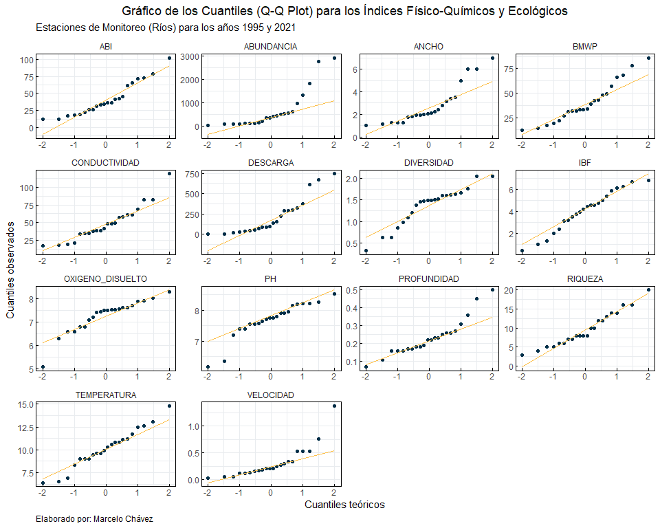

```r
numeric_vars <- indices_fq_ddc[sapply(indices_fq_ddc, is.numeric)]

# Convertir el dataframe en formato largo (long format) para usar facet_wrap
df_long <- tidyr::pivot_longer(numeric_vars, cols = everything())

# Crear el Q-Q plot con facet_wrap
ggplot(df_long, aes(sample = value)) +
    geom_qq(color = "#003049") +
    stat_qq_line(color = "#fcbf49") +
    labs(
        title = "Gráfico de los Cuantiles (Q-Q Plot) para los Índices Físico-Químicos y Ecológicos",
        subtitle = "Estaciones de Monitoreo (Ríos) para los años 1995 y 2021",
        x = "Cuantiles teóricos",
        y = "Cuantiles observados",
        caption = "Elaborado por: Marcelo Chávez"
    ) +
    facet_wrap(~ name, scales = "free") +
    theme_minimal() +
    theme(
        panel.grid = element_line(color = "#e9ecef", size = 0.5),  # Añadir grid
        panel.border = element_rect(color = "black", fill = NA),  # Añadir recuadro
        axis.ticks = element_line(color = "black"),  # Añadir ticks en los ejes
        axis.line = element_blank(),  # Eliminar líneas de ejes interiores
        plot.title = element_text(hjust = 0.5),  # Centrar el título
        plot.caption = element_text(hjust = 0),  # Alinear el footnote a la izquierda
        axis.ticks.length = unit(-0.1, "cm")  # Ajustar longitud de los ticks hacia adentro
    )
```

## 2.1 Test No paramétrico de **Shapiro-Wilks** para evaluar la normalidad en las variables físico-químicas y ecológicas:

**Código**

```r
# Definir una función para aplicar el test de Shapiro-Wilk a todas las variables numéricas
shapiro_test_all <- function(df) {

  # Filtrar solo las variables numéricas
  numeric_vars <- df[sapply(df, is.numeric)]

  # Crear una lista para almacenar los resultados del test
  test_results <- list()

  # Iterar sobre cada variable numérica y aplicar el test de Shapiro-Wilk
  for (var_name in names(numeric_vars)) {

    result <- shapiro.test(numeric_vars[[var_name]])

    # Redondear el estadístico W y el valor p a dos decimales
    result$statistic <- round(result$statistic, 2)

    result$p.value <- round(result$p.value, 2)

    test_results[[var_name]] <- result
  }

  # Retornar los resultados como una lista
  return(test_results)
}

# Aplicar la función al dataframe indices_fq_ddc
shapiro_results <- shapiro_test_all(indices_fq_ddc)

# Convertir los resultados en un tibble
results_df <- tibble::enframe(shapiro_results,
                              name = "Variable",
                              value = "Resultados")

# Extraer los estadísticos W y los valores p en columnas separadas
results_df <- results_df %>%
  mutate(W = sapply(Resultados,
                    "[[",
                    "statistic"),

         p_value = sapply(Resultados,
                          "[[",
                          "p.value"))

# Seleccionar las columnas relevantes
results_df <- results_df %>%
  select(Variable, W, p_value)

# Definir los niveles de significancia
significance_levels <- c(0.05, 0.01, 0.10)

# Función para determinar si el valor p es mayor o menor que un nivel de significancia dado
check_significance <- function(p_value,
                               significance_level) {

  if (p_value < significance_level) {
    return("Menor al $\\alpha$")
  } else {
    return("Mayor o igual $\\alpha$")
  }
}

# Aplicar la función a cada valor p y nivel de significancia
for (level in significance_levels) {

  results_df <- results_df %>%
    mutate(
      !!paste0("Nivel de Significancia al ",
               level) := sapply(p_value,
                                check_significance,
                                significance_level = level),
      !!paste0("Rechazas H0 al ",
               level) := ifelse(p_value < level,
                                "Sí",
                                "No")
    )
}

# Mostrar la tabla actualizada
knitr::kable(results_df, format = "markdown")
```

| Variable | W | p_value | Nivel de Significancia al 0.05 | Rechazas H0 al 0.05 | Nivel de Significancia al 0.01 | Rechazas H0 al 0.01 | Nivel de Significancia al 0.1 | Rechazas H0 al 0.1 |
| --- | --- | --- | --- | --- | --- | --- | --- | --- |
| ANCHO | 0.83 | 0.00 | Menor al $\alpha$ | Sí | Menor al $\alpha$ | Sí | Menor al $\alpha$ | Sí |
| PROFUNDIDAD | 0.90 | 0.03 | Menor al $\alpha$ | Sí | Mayor o igual $\alpha$ | No | Menor al $\alpha$ | Sí |
| VELOCIDAD | 0.75 | 0.00 | Menor al $\alpha$ | Sí | Menor al $\alpha$ | Sí | Menor al $\alpha$ | Sí |
| DESCARGA | 0.83 | 0.00 | Menor al $\alpha$ | Sí | Menor al $\alpha$ | Sí | Menor al $\alpha$ | Sí |
| PH | 0.88 | 0.01 | Menor al $\alpha$ | Sí | Mayor o igual $\alpha$ | No | Menor al $\alpha$ | Sí |
| TEMPERATURA | 0.98 | 0.84 | Mayor o igual $\alpha$ | No | Mayor o igual $\alpha$ | No | Mayor o igual $\alpha$ | No |
| OXIGENO_DISUELTO | 0.88 | 0.01 | Menor al $\alpha$ | Sí | Mayor o igual $\alpha$ | No | Menor al $\alpha$ | Sí |
| CONDUCTIVIDAD | 0.92 | 0.07 | Mayor o igual $\alpha$ | No | Mayor o igual $\alpha$ | No | Menor al $\alpha$ | Sí |
| RIQUEZA | 0.95 | 0.33 | Mayor o igual $\alpha$ | No | Mayor o igual $\alpha$ | No | Mayor o igual $\alpha$ | No |
| ABUNDANCIA | 0.71 | 0.00 | Menor al $\alpha$ | Sí | Menor al $\alpha$ | Sí | Menor al $\alpha$ | Sí |
| DIVERSIDAD | 0.92 | 0.07 | Mayor o igual $\alpha$ | No | Mayor o igual $\alpha$ | No | Menor al $\alpha$ | Sí |
| ABI | 0.91 | 0.04 | Menor al $\alpha$ | Sí | Mayor o igual $\alpha$ | No | Menor al $\alpha$ | Sí |
| BMWP | 0.94 | 0.16 | Mayor o igual $\alpha$ | No | Mayor o igual $\alpha$ | No | Mayor o igual $\alpha$ | No |
| IBF | 0.96 | 0.60 | Mayor o igual $\alpha$ | No | Mayor o igual $\alpha$ | No | Mayor o igual $\alpha$ | No |

## 2.2 Comprobación de hipótesis para análisis normalidad:

Para la comprobaciónd de normalidad se ha planteado la siguiente prueba de hipótesis:

$H_{0}:$ Las variables provienen de una Distribución Normal

$H_{1}:$ Las variables NO provienen de una Distribución Normal

# 3 Análisis Factorial por Componentes Principales:

Para la **Modelización Factorial** emplearemos los siguientes pasos:

### 3.0.1 Flujo del Modelo Factorial

**Código**

```
graph TD;
    A(Matriz de correlaciones y su significancia estadística) -->
    B(Determinante de la matriz de correlaciones);
    B --> C(Prueba de esfericidad de Bartlett);
    C --> D(Comprobación de hipótesis para el análisis factorial por componentes principales);
    D --> E(Gráfico de Sedimentación);
    E --> F(Proporción de Varianza Acumulada);
    F --> G(Componentes Principales);
    G --> H(Autovalores y Varianzas);
    H --> I(Círculo de las Correlaciones);
    I --> J(Variables versus Dimensiones);
    J --> K(Biplot);
```

```
graph TD;
    A(Matriz de correlaciones y su significancia estadística) -->
    B(Determinante de la matriz de correlaciones);
    B --> C(Prueba de esfericidad de Bartlett);
    C --> D(Comprobación de hipótesis para el análisis factorial por componentes principales);
    D --> E(Gráfico de Sedimentación);
    E --> F(Proporción de Varianza Acumulada);
    F --> G(Componentes Principales);
    G --> H(Autovalores y Varianzas);
    H --> I(Círculo de las Correlaciones);
    I --> J(Variables versus Dimensiones);
    J --> K(Biplot);
```

Se ha tomado como referencia los pasos indicados en el libro (Hair et al. 1999).

## 3.1 Matriz de Correlaciones:

**Código**

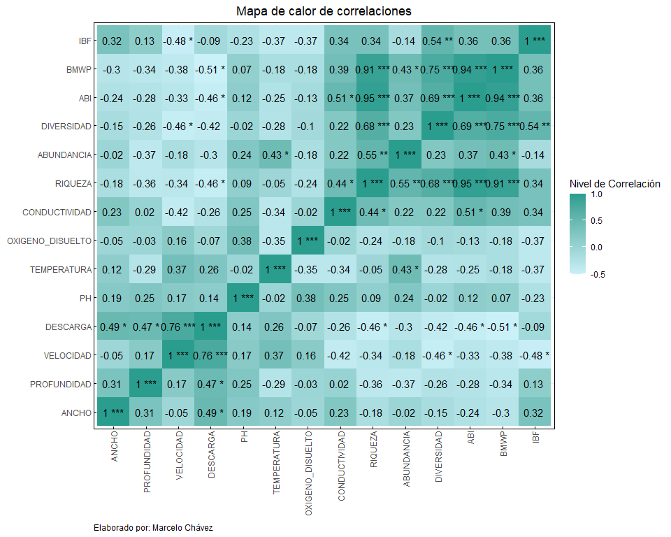

```r
# Calcular correlaciones y p-values
correlation_matrix <- cor(indices_fq_ddc)
p_values <- cor.mtest(indices_fq_ddc)$p

# Convertir p-values en asteriscos de acuerdo con el nivel de significancia
significant_level <- ifelse(p_values < 0.001, "***",
                            ifelse(p_values < 0.01, "**",
                                   ifelse(p_values < 0.05, "*", "")))

# Crear gráfico
ggplot(data = melt(round(correlation_matrix, 2)), aes(x = Var1, y = Var2, fill = value)) +
    geom_tile() +
    geom_text(aes(label = paste(round(value, 2), significant_level)), color = "black", size = 4) +
    labs(
        title = "Mapa de calor de correlaciones",
        x = "",
        y = "",
        fill = "Nivel de Correlación",
        caption = "Elaborado por: Marcelo Chávez"
    ) +
    scale_fill_gradient(low = "#caf0f8", high = "#2a9d8f") +
    theme_minimal() +
    theme(
        axis.text.x = element_text(angle = 90, vjust = 0.5, hjust = 1),
        axis.title.x = element_text(angle = 90),
        axis.title.y = element_text(angle = 0),
        panel.grid = element_line(color = "#e9ecef", linewidth = 0.5),  # Cambio a linewidth
        panel.border = element_rect(color = "black", fill = NA),
        axis.ticks = element_line(color = "black"),
        axis.line = element_blank(),
        plot.title = element_text(hjust = 0.5),
        plot.caption = element_text(hjust = 0),
        axis.ticks.length = unit(-0.1, "cm")
    )
```

> Es importante conocer que el nivel de significancia de la matriz de correlaciones para definir variables que a más de tener un buen nivel de correlación, es significativo estadísticamente.

## 3.2 Determinante de la matriz de correlaciones

**Código**

```r
det(cor(indices_fq_ddc))
```

```
[1] 1.747507e-07
```

> Si están correlacionadas, el determinantes de la matriz de correlaciones será próximo a cero. De lo contrario el **Análisis Factorial** no es viable.

## 3.3 Prueba de esfericidad de Bartlett:

**Código**

```r
KMO(indices_fq_ddc)
```

```
Kaiser-Meyer-Olkin factor adequacy
Call: KMO(r = indices_fq_ddc)
Overall MSA =  0.44
MSA for each item =
           ANCHO      PROFUNDIDAD        VELOCIDAD         DESCARGA
            0.17             0.73             0.32             0.37
              PH      TEMPERATURA OXIGENO_DISUELTO    CONDUCTIVIDAD
            0.47             0.28             0.15             0.51
         RIQUEZA       ABUNDANCIA       DIVERSIDAD              ABI
            0.63             0.40             0.64             0.49
            BMWP              IBF
            0.62             0.48
```

**Código**

```r
cortest.bartlett(cor(indices_fq_ddc))
```

```
$chisq
[1] 1454.851

$p.value
[1] 1.621989e-244

$df
[1] 91
```

> Un KMO de 0.44 es considerado bajo y podría sugerir que un análisis factorial puede no ser adecuado para estos datos. Sin embargo, la prueba de Bartlett tiene un p-valor menor al nivel de significancia del 5%, lo que indica que las variables están correlacionadas y que, por lo tanto, podría justificarse aplicar un método multivariante para reducción de dimensionalidad.

> La hipótesis nula es que la matriz de correlaciones es una matriz identidad, lo que significa que no existirían correlaciones significativas, por lo que el modelo factorial no sería pertinente.

## 3.4 Comprobación de hipótesis para el análisis factorial por componentes principales

$H_{0}:$ Existe esfericidad

$H_{1}:$ No existe esfericidad

> La esfericidad implica que todas las variables tienen la misma varianza y que no hay correlaciones entre ellas.

## 3.5 Gráfico de Sedimentación:

**Código**

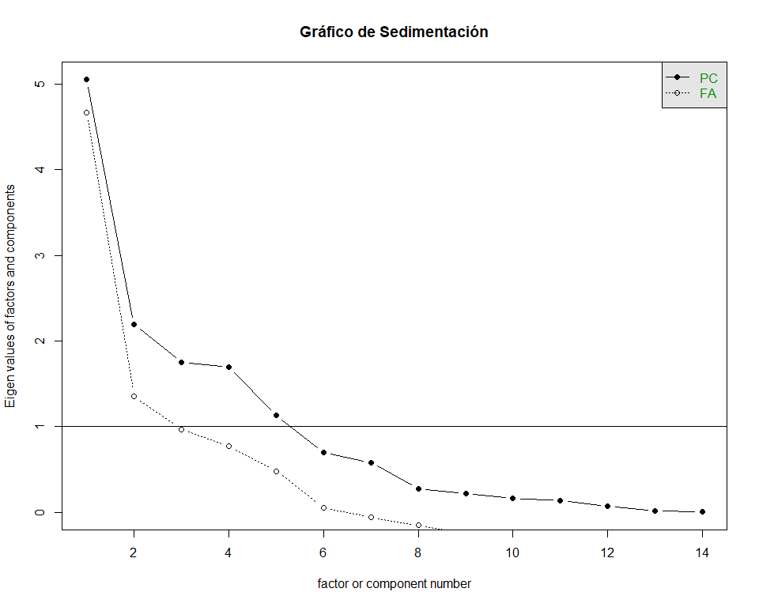

```r
scree(indices_fq_ddc,
      main ="Gráfico de Sedimentación")
```

## 3.6 Proporción de varianza acumulada:

**Código**

```r
# Cálculo de los autovalores y autovectores:
value_pro<-eigen(cor(indices_fq_ddc))

Acumulado <- cumsum(value_pro$values)

Prop.acumulado <- Acumulado/sum(value_pro$values)

val.prop.porce <- data.frame(value_pro$values,
                             Acumulado,
                             Prop.acumulado)

row.names(val.prop.porce) = c(expression(lambda[1]),
                              expression(lambda[2]),
                              expression(lambda[3]),
                              expression(lambda[4]),
                              expression(lambda[5]),
                              expression(lambda[6]),
                              expression(lambda[7]),
                              expression(lambda[8]),
                              expression(lambda[9]),
                              expression(lambda[10]),
                              expression(lambda[11]),
                              expression(lambda[12]),
                              expression(lambda[13]),
                              expression(lambda[14]))

colnames(val.prop.porce) <- c("Valor Propio",
                              "Acumulado",
                              "Prop. Acumulado")
kable(val.prop.porce,
      caption = "Valores propios desde la matriz de correlaciones",
      digits = 2,
      format.args = list(decimal.mark =",")) %>%
  row_spec(row = 5,
           background="#a7c957",
           bold=T)
```

Valores propios desde la matriz de correlaciones

|  | Valor Propio | Acumulado | Prop. Acumulado |
| --- | --- | --- | --- |
| lambda[1] | 5,05 | 5,05 | 0,36 |
| lambda[2] | 2,19 | 7,25 | 0,52 |
| lambda[3] | 1,75 | 9,00 | 0,64 |
| lambda[4] | 1,70 | 10,69 | 0,76 |
| lambda[5] | 1,13 | 11,83 | 0,84 |
| lambda[6] | 0,70 | 12,53 | 0,89 |
| lambda[7] | 0,58 | 13,11 | 0,94 |
| lambda[8] | 0,28 | 13,38 | 0,96 |
| lambda[9] | 0,22 | 13,60 | 0,97 |
| lambda[10] | 0,16 | 13,76 | 0,98 |
| lambda[11] | 0,14 | 13,90 | 0,99 |
| lambda[12] | 0,07 | 13,98 | 1,00 |
| lambda[13] | 0,02 | 13,99 | 1,00 |
| lambda[14] | 0,01 | 14,00 | 1,00 |

> El **Valor Propio** de la matriz de correlaciones cuando desciende hasta 1 sugiere que el número de componentes o factores que pueden explicar la variabilidad de todo el conjunto de datos está en un $\lambda=5$ y lo corrobora el **Gráfico de Sedimentación**

## 3.7 Componentes Principales:

En la ejecución de las componentes principales emplearemos un método de estandarización de variables respecto a su media ($\bar{x}$) y desviación estándar ($\sigma$) (Wang, Sun, y Luan 2024)

**Código**

```r
pca <- prcomp(indices_fq_ddc,
              scale=TRUE,
              center = TRUE,
              method = "varimax")
summary(pca)
```

```
Importance of components:
                         PC1    PC2    PC3    PC4     PC5     PC6     PC7
Standard deviation     2.248 1.4804 1.3231 1.3023 1.06484 0.83589 0.76202
Proportion of Variance 0.361 0.1565 0.1250 0.1211 0.08099 0.04991 0.04148
Cumulative Proportion  0.361 0.5176 0.6426 0.7638 0.84475 0.89466 0.93614
                          PC8    PC9    PC10    PC11    PC12    PC13    PC14
Standard deviation     0.5252 0.4688 0.40051 0.37373 0.27113 0.13661 0.07873
Proportion of Variance 0.0197 0.0157 0.01146 0.00998 0.00525 0.00133 0.00044
Cumulative Proportion  0.9558 0.9715 0.98300 0.99297 0.99822 0.99956 1.00000
```

## 3.8 Autovalores y varianzas:

**Código**

```r
get_eig(pca)
```

```
        eigenvalue variance.percent cumulative.variance.percent
Dim.1  5.054291459      36.10208185                    36.10208
Dim.2  2.191655745      15.65468390                    51.75677
Dim.3  1.750665400      12.50475286                    64.26152
Dim.4  1.696074162      12.11481544                    76.37633
Dim.5  1.133880767       8.09914834                    84.47548
Dim.6  0.698704553       4.99074681                    89.46623
Dim.7  0.580677202       4.14769430                    93.61392
Dim.8  0.275814651       1.97010465                    95.58403
Dim.9  0.219778973       1.56984981                    97.15388
Dim.10 0.160411780       1.14579843                    98.29968
Dim.11 0.139674537       0.99767527                    99.29735
Dim.12 0.073509242       0.52506601                    99.82242
Dim.13 0.018663566       0.13331119                    99.95573
Dim.14 0.006197963       0.04427116                   100.00000
```

> Al analizar los componentes principales podemos observar que en el **Componente 5** se explica el **84%** de la varianza de todas las dimensiones

## 3.9 Círculo de correlaciones:

**Código**

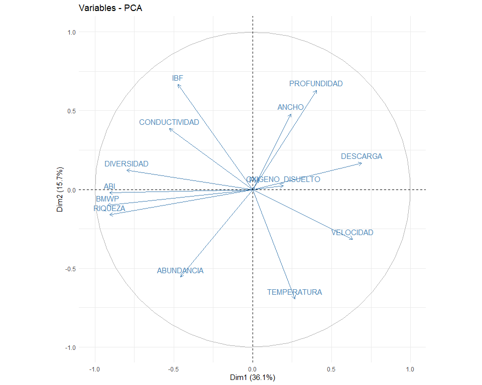

```r
fviz_pca_var(pca,
             col.var="steelblue") +
  theme_minimal()
```

**Código**

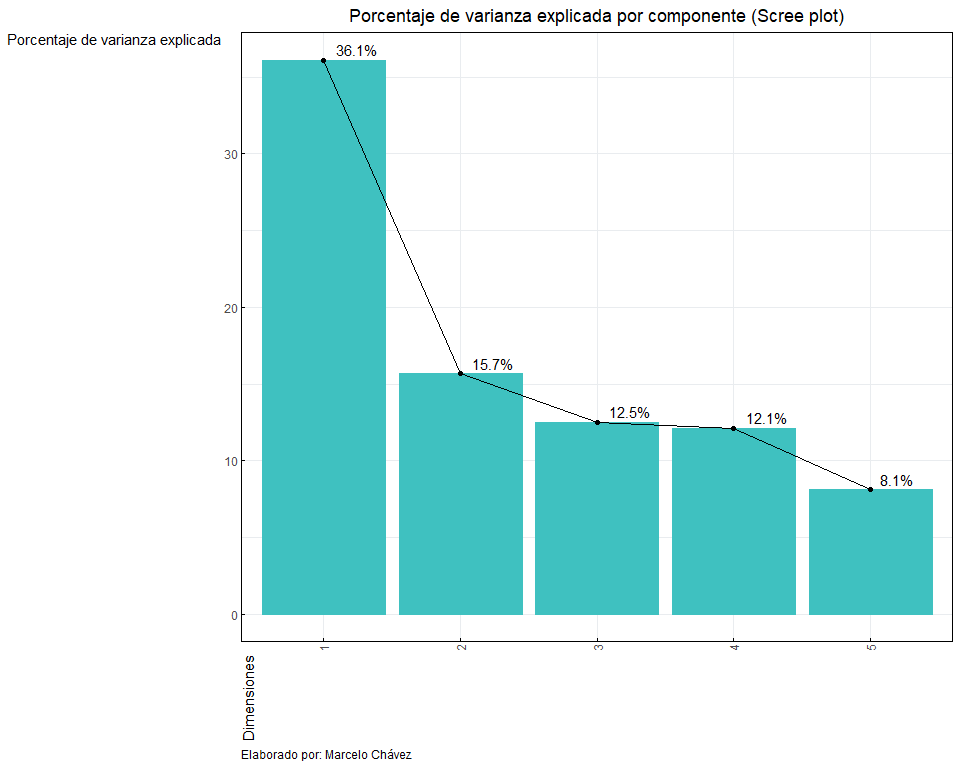

```r
fviz_screeplot(pca,
               ncp = 5,
               barfill = "#3fc1c0",
               barcolor = "#3fc1c0",
               addlabels = TRUE,
               ylab = "Porcentaje de varianza explicada",
               xlab = "Dimensiones",
               main = "Porcentaje de varianza explicada por componente (Scree plot)",
               hjust = -0.3) +
  theme(plot.title = element_text(size = 14, face = "bold"),
        plot.caption = element_text(size = 8, face = "italic")) +
  labs(caption = "Elaborado por: Marcelo Chávez") +
  theme_minimal() +
    theme(
        axis.text.x = element_text(angle = 90, vjust = 0.5, hjust = 1),
        axis.title.x = element_text(angle = 90),
        axis.title.y = element_text(angle = 0),
        panel.grid = element_line(color = "#e9ecef", linewidth = 0.5),  # Cambio a linewidth
        panel.border = element_rect(color = "black", fill = NA),
        axis.ticks = element_line(color = "black"),
        axis.line = element_blank(),
        plot.title = element_text(hjust = 0.5),
        plot.caption = element_text(hjust = 0),
        axis.ticks.length = unit(-0.1, "cm")
    )
```

## 3.10 Variables versus Dimensiones:

**Código**

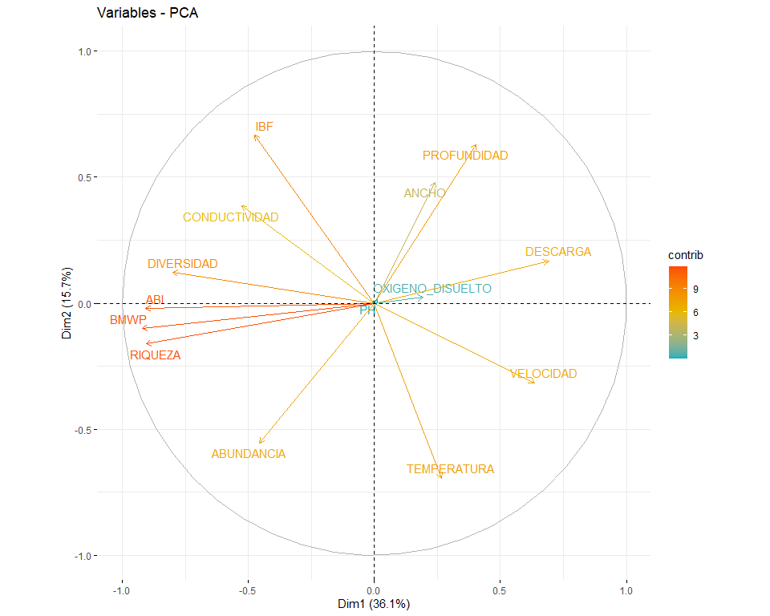

```r
fviz_pca_var(pca,
             col.var="contrib",
             gradient.cols = c("#00AFBB", "#E7B800", "#FC4E07"),
             repel = TRUE)
```

## 3.11 Biplot (variables versus las estaciones de monitoreo)

**Código**

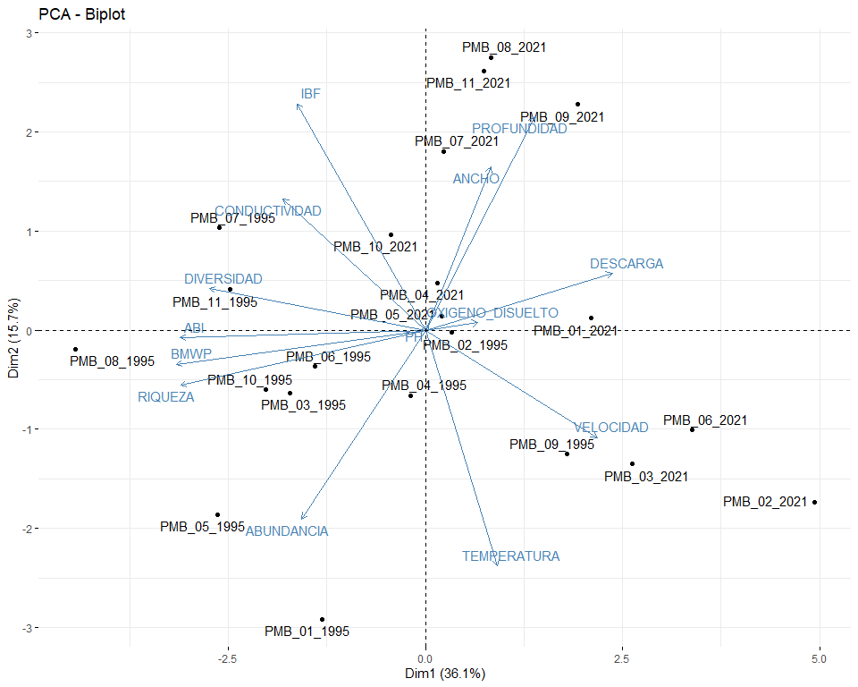

```r
# Biplot of individuals and variables
fviz_pca_biplot(pca, repel = TRUE)
```

> Variables ecológicas como **ABI, BMWP y RIQUEZA** exhiben una alta similitud en la estación de monitoreo 8 durante el año 1995. De manera similar: **CONDUCTIVIDAD, DIVERSIDAD e IBF** comparten características destacadas en las estaciones de monitoreo 7 y 11, también en el año 1995. Por otro lado, un conjunto distinto de variables como: **ANCHO, PROFUNDIDAD y DESCARGA** para el año 2021, evidencian patrones similares en las estaciones de monitoreo 1, 7, 8 y 9. Sin embargo, variables como: **ABUNDANCIA, TEMPERATURA y VELOCIDAD**, a pesar de su comportamiento de no similaridad entre ellas, aportan de forma significativa al modelo factorial individualmente